# StatComp Project 2: Scottish weather

# 2 Spatial weather prediction

## 2.1 Estimation and prediction

In spatial weather prediction, a new variable called Value_sqrt_avg is constructed, which is the square root of the monthly averaged precipitation values. This is done because the precipitation values are highly skewed and the variance increases with the mean value, making it difficult to create a model with constant variance. By taking the square root of the monthly averages, this issue is alleviated and a constant-variance model becomes more plausible.

For estimation and prediction, models are defined and estimated for the square root of the monthly averaged precipitation values in Scotland. The basic model, $M_0$, uses a combination of “Longitude”, “Latitude”, “Elevation”, and “DecYear” as independent variables to capture seasonal variability. Additional covariates $\cos(2 \pi kt)$ and $\sin(2\pi kt)$ that vary with the “DecYear” variable are added to $M_0$ to model seasonal variability in models $M_1$, $M_2$, $M_3$, and $M_4$.

To compare the models, various statistics such as the F-statistic, p-values for the F-statistic and individual regression coefficients, and the residual standard error were used. Here, the model estimation results for $M_0$ to $M_4$ are displayed below.

```r
ghcnd_values_sqrt <- ghcnd_values %>%
  filter(Element == "PRCP") %>%
  group_by(ID, Year, Month) %>%
  summarise(Value_sqrt_avg = sqrt(mean(Value)), DecYear = mean(DecYear), .groups="drop") %>%
  left_join(ghcnd_stations %>% select(ID, Name, Longitude, Latitude, Elevation), by = "ID")
ghcnd_values_sqrt
```

```
## # A tibble: 5,447 × 9
##    ID           Year Month Value_sqrt_avg DecYear Name   Longi…¹ Latit…² Eleva…³
##    <chr>       <int> <int>          <dbl>   <dbl> <chr>    <dbl>   <dbl>   <dbl>
##  1 UKE00105874  1961     1          1.52    1961. BRAEM…   -3.40    57.0     339
##  2 UKE00105874  1961     2          1.37    1961. BRAEM…   -3.40    57.0     339
##  3 UKE00105874  1961     3          0.900   1961. BRAEM…   -3.40    57.0     339
##  4 UKE00105874  1961     4          1.31    1961. BRAEM…   -3.40    57.0     339
##  5 UKE00105874  1961     5          1.09    1961. BRAEM…   -3.40    57.0     339
##  6 UKE00105874  1961     6          0.918   1961. BRAEM…   -3.40    57.0     339
##  7 UKE00105874  1961     7          1.62    1962. BRAEM…   -3.40    57.0     339
##  8 UKE00105874  1961     8          1.80    1962. BRAEM…   -3.40    57.0     339
##  9 UKE00105874  1961     9          1.80    1962. BRAEM…   -3.40    57.0     339
## 10 UKE00105874  1961    10          2.26    1962. BRAEM…   -3.40    57.0     339
## # … with 5,437 more rows, and abbreviated variable names ¹Longitude, ²Latitude,
## #   ³Elevation
```

```r
# M0 model
M0 <- lm(Value_sqrt_avg ~ Longitude + Latitude + Elevation + DecYear, data = ghcnd_values_sqrt)
print(summary(M0))
```

```
##
## Call:
## lm(formula = Value_sqrt_avg ~ Longitude + Latitude + Elevation +
##     DecYear, data = ghcnd_values_sqrt)
##
## Residuals:
##      Min       1Q   Median       3Q      Max
## -1.94594 -0.32642 -0.02307  0.30481  1.95082
##
## Coefficients:
##               Estimate Std. Error t value Pr(>|t|)
## (Intercept)  2.477e+00  1.394e+00   1.777   0.0757 .
## Longitude   -5.464e-01  1.073e-02 -50.930  < 2e-16 ***
## Latitude    -1.360e-01  2.018e-02  -6.737 1.79e-11 ***
## Elevation    4.022e-04  7.689e-05   5.231 1.75e-07 ***
## DecYear      2.411e-03  3.968e-04   6.076 1.31e-09 ***
## ---
## Signif. codes:  0 '***' 0.001 '**' 0.01 '*' 0.05 '.' 0.1 ' ' 1
##
## Residual standard error: 0.4902 on 5442 degrees of freedom
## Multiple R-squared:  0.3424, Adjusted R-squared:  0.3419
## F-statistic: 708.3 on 4 and 5442 DF,  p-value: < 2.2e-16
```

```r
# M1 model
M1 <- lm(Value_sqrt_avg ~ Longitude + Latitude + Elevation + DecYear +
           cos(2*pi*DecYear) + sin(2*pi*DecYear), data = ghcnd_values_sqrt)
print(summary(M1))
```

```
##
## Call:
## lm(formula = Value_sqrt_avg ~ Longitude + Latitude + Elevation +
##     DecYear + cos(2 * pi * DecYear) + sin(2 * pi * DecYear),
##     data = ghcnd_values_sqrt)
##
## Residuals:
##      Min       1Q   Median       3Q      Max
## -1.98638 -0.30492 -0.01175  0.29335  1.89615
##
## Coefficients:
##                         Estimate Std. Error t value Pr(>|t|)
## (Intercept)            2.490e+00  1.319e+00   1.888   0.0591 .
## Longitude             -5.467e-01  1.015e-02 -53.862  < 2e-16 ***
## Latitude              -1.350e-01  1.909e-02  -7.069 1.76e-12 ***
## Elevation              4.040e-04  7.274e-05   5.554 2.92e-08 ***
## DecYear                2.376e-03  3.754e-04   6.329 2.67e-10 ***
## cos(2 * pi * DecYear)  1.828e-01  8.902e-03  20.536  < 2e-16 ***
## sin(2 * pi * DecYear) -1.320e-01  8.870e-03 -14.885  < 2e-16 ***
## ---
## Signif. codes:  0 '***' 0.001 '**' 0.01 '*' 0.05 '.' 0.1 ' ' 1
##
## Residual standard error: 0.4637 on 5440 degrees of freedom
## Multiple R-squared:  0.4117, Adjusted R-squared:  0.411
## F-statistic: 634.5 on 6 and 5440 DF,  p-value: < 2.2e-16
```

```r
# M2 model
M2 <- lm(Value_sqrt_avg ~ Longitude + Latitude + Elevation + DecYear +
           cos(2*pi*DecYear) + sin(2*pi*DecYear) +
           cos(4*pi*DecYear) + sin(4*pi*DecYear), data = ghcnd_values_sqrt)
print(summary(M2))
```

```
##
## Call:
## lm(formula = Value_sqrt_avg ~ Longitude + Latitude + Elevation +
##     DecYear + cos(2 * pi * DecYear) + sin(2 * pi * DecYear) +
##     cos(4 * pi * DecYear) + sin(4 * pi * DecYear), data = ghcnd_values_sqrt)
##
## Residuals:
##      Min       1Q   Median       3Q      Max
## -1.98846 -0.30883 -0.01187  0.29641  1.89402
##
## Coefficients:
##                         Estimate Std. Error t value Pr(>|t|)
## (Intercept)            2.477e+00  1.318e+00   1.879 0.060239 .
## Longitude             -5.467e-01  1.014e-02 -53.911  < 2e-16 ***
## Latitude              -1.349e-01  1.907e-02  -7.075 1.69e-12 ***
## Elevation              4.042e-04  7.267e-05   5.562 2.80e-08 ***
## DecYear                2.382e-03  3.750e-04   6.351 2.31e-10 ***
## cos(2 * pi * DecYear)  1.829e-01  8.894e-03  20.567  < 2e-16 ***
## sin(2 * pi * DecYear) -1.321e-01  8.862e-03 -14.903  < 2e-16 ***
## cos(4 * pi * DecYear)  3.088e-02  8.889e-03   3.474 0.000516 ***
## sin(4 * pi * DecYear)  7.686e-04  8.866e-03   0.087 0.930922
## ---
## Signif. codes:  0 '***' 0.001 '**' 0.01 '*' 0.05 '.' 0.1 ' ' 1
##
## Residual standard error: 0.4633 on 5438 degrees of freedom
## Multiple R-squared:  0.413,  Adjusted R-squared:  0.4121
## F-statistic: 478.3 on 8 and 5438 DF,  p-value: < 2.2e-16
```

```r
# M3 model
M3 <- lm(Value_sqrt_avg ~ Longitude + Latitude + Elevation + DecYear +
           cos(2*pi*DecYear) + sin(2*pi*DecYear) +
           cos(4*pi*DecYear) + sin(4*pi*DecYear) +
           cos(6*pi*DecYear) + sin(6*pi*DecYear), data = ghcnd_values_sqrt)
print(summary(M3))
```

```
##
## Call:
## lm(formula = Value_sqrt_avg ~ Longitude + Latitude + Elevation +
##     DecYear + cos(2 * pi * DecYear) + sin(2 * pi * DecYear) +
##     cos(4 * pi * DecYear) + sin(4 * pi * DecYear) + cos(6 * pi *
##     DecYear) + sin(6 * pi * DecYear), data = ghcnd_values_sqrt)
##
## Residuals:
##      Min       1Q   Median       3Q      Max
## -2.01405 -0.30872 -0.01268  0.29559  1.86840
##
## Coefficients:
##                         Estimate Std. Error t value Pr(>|t|)
## (Intercept)            2.470e+00  1.317e+00   1.876 0.060694 .
## Longitude             -5.467e-01  1.013e-02 -53.958  < 2e-16 ***
## Latitude              -1.349e-01  1.906e-02  -7.080 1.62e-12 ***
## Elevation              4.044e-04  7.261e-05   5.570 2.67e-08 ***
## DecYear                2.385e-03  3.747e-04   6.364 2.12e-10 ***
## cos(2 * pi * DecYear)  1.828e-01  8.887e-03  20.568  < 2e-16 ***
## sin(2 * pi * DecYear) -1.321e-01  8.855e-03 -14.915  < 2e-16 ***
## cos(4 * pi * DecYear)  3.072e-02  8.882e-03   3.459 0.000546 ***
## sin(4 * pi * DecYear)  5.964e-04  8.859e-03   0.067 0.946329
## cos(6 * pi * DecYear) -7.072e-03  8.868e-03  -0.797 0.425214
## sin(6 * pi * DecYear)  2.854e-02  8.872e-03   3.217 0.001305 **
## ---
## Signif. codes:  0 '***' 0.001 '**' 0.01 '*' 0.05 '.' 0.1 ' ' 1
##
## Residual standard error: 0.4629 on 5436 degrees of freedom
## Multiple R-squared:  0.4142, Adjusted R-squared:  0.4131
## F-statistic: 384.3 on 10 and 5436 DF,  p-value: < 2.2e-16
```

```r
# M4 model
M4 <- lm(Value_sqrt_avg ~ Longitude + Latitude + Elevation + DecYear +
           cos(2*pi*DecYear) + sin(2*pi*DecYear) +
           cos(4*pi*DecYear) + sin(4*pi*DecYear) +
           cos(6*pi*DecYear) + sin(6*pi*DecYear) +
           cos(8*pi*DecYear) + sin(8*pi*DecYear), data = ghcnd_values_sqrt)
print(summary(M4))
```

```
##
## Call:
## lm(formula = Value_sqrt_avg ~ Longitude + Latitude + Elevation +
##     DecYear + cos(2 * pi * DecYear) + sin(2 * pi * DecYear) +
##     cos(4 * pi * DecYear) + sin(4 * pi * DecYear) + cos(6 * pi *
##     DecYear) + sin(6 * pi * DecYear) + cos(8 * pi * DecYear) +
##     sin(8 * pi * DecYear), data = ghcnd_values_sqrt)
##
## Residuals:
##      Min       1Q   Median       3Q      Max
## -2.00162 -0.30627 -0.01235  0.29501  1.88086
##
## Coefficients:
##                         Estimate Std. Error t value Pr(>|t|)
## (Intercept)            2.471e+00  1.317e+00   1.877  0.06056 .
## Longitude             -5.467e-01  1.013e-02 -53.968  < 2e-16 ***
## Latitude              -1.350e-01  1.906e-02  -7.083 1.59e-12 ***
## Elevation              4.042e-04  7.259e-05   5.568 2.70e-08 ***
## DecYear                2.385e-03  3.747e-04   6.366 2.09e-10 ***
## cos(2 * pi * DecYear)  1.829e-01  8.886e-03  20.578  < 2e-16 ***
## sin(2 * pi * DecYear) -1.320e-01  8.853e-03 -14.916  < 2e-16 ***
## cos(4 * pi * DecYear)  3.070e-02  8.880e-03   3.457  0.00055 ***
## sin(4 * pi * DecYear)  6.781e-04  8.857e-03   0.077  0.93897
## cos(6 * pi * DecYear) -7.045e-03  8.867e-03  -0.795  0.42691
## sin(6 * pi * DecYear)  2.849e-02  8.870e-03   3.212  0.00133 **
## cos(8 * pi * DecYear)  1.356e-02  8.900e-03   1.524  0.12763
## sin(8 * pi * DecYear)  1.223e-02  8.838e-03   1.384  0.16656
## ---
## Signif. codes:  0 '***' 0.001 '**' 0.01 '*' 0.05 '.' 0.1 ' ' 1
##
## Residual standard error: 0.4628 on 5434 degrees of freedom
## Multiple R-squared:  0.4146, Adjusted R-squared:  0.4134
## F-statistic: 320.8 on 12 and 5434 DF,  p-value: < 2.2e-16
```

A higher F-statistic indicates a better fit to the data, while a lower p-value for the F-statistic indicates stronger evidence against the null hypothesis. Lower p-values for the individual regression coefficients also indicate a stronger relationship between the variable and the response variable. A lower residual standard error indicates a better fit to the data.

## 2.2 Assessment: Station and season differences

To evaluate how well the model can predict precipitation at new locations, we employ a stratified cross-validation approach that groups data by weather station. For each station, we fit the model on all other stations and calculate the prediction scores on the held-out station’s data. We then aggregate the scores for each station and compute the overall cross-validated average scores for each month of the year.

Two different score metrics, namely Squared Error (SE) and Dawid-Sebastiani (DS) scores, are used to assess the model’s predictive performance. The SE score calculates the average squared difference between observed and predicted values, while the DS score is a probabilistic measure that evaluates the model’s predicted probabilities against observed frequencies.

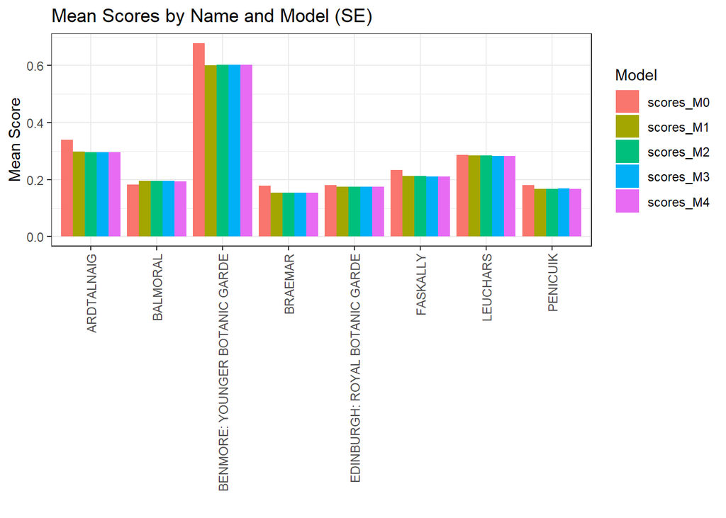

```r
df_se <- data.frame(
  Name = mean_score_M0$Name,
  scores_M0 = mean_score_M0$mean_pred_score,
  scores_M1 = mean_score_M1$mean_pred_score,
  scores_M2 = mean_score_M2$mean_pred_score,
  scores_M3 = mean_score_M3$mean_pred_score,
  scores_M4 = mean_score_M4$mean_pred_score
)

# reshape the data into long format
df_long_se <- reshape2::melt(df_se, id.vars = "Name", variable.name = "Model", value.name = "MeanScore")

# create a bar chart for se scores
ggplot(df_long_se, aes(x = Name, y = MeanScore, fill = Model)) +
  geom_bar(stat = "identity", position = "dodge") +
  labs(x = "", y = "Mean Score", fill = "Model") +
  ggtitle("Mean Scores by Name and Model (SE)") +
  theme(axis.text.x = element_text(angle = 90, hjust = 1, vjust = 0.5))
```

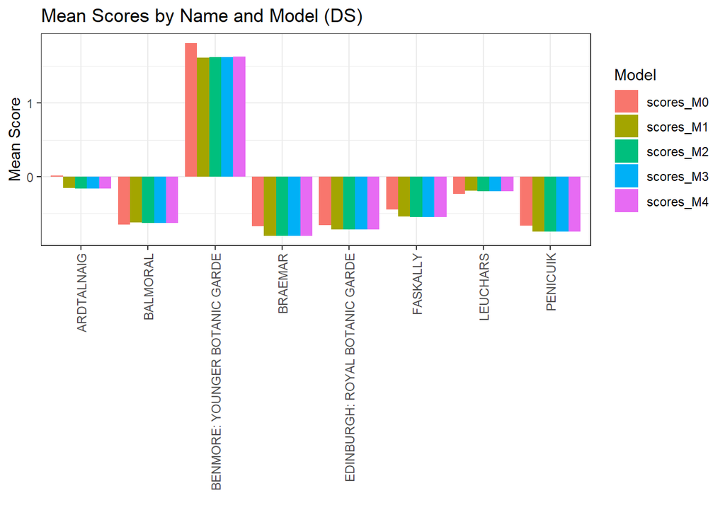

```r
df_ds <- data.frame(
  Name = mean_score1_M0$Name,
  scores_M0 = mean_score1_M0$mean_pred_score,
  scores_M1 = mean_score1_M1$mean_pred_score,
  scores_M2 = mean_score1_M2$mean_pred_score,
  scores_M3 = mean_score1_M3$mean_pred_score,
  scores_M4 = mean_score1_M4$mean_pred_score
)

# reshape the data into long format
df_long_ds <- reshape2::melt(df_ds, id.vars = "Name", variable.name = "Model", value.name = "MeanScore")

# create a bar chart for se scores
ggplot(df_long_ds, aes(x = Name, y = MeanScore, fill = Model)) +
  geom_bar(stat = "identity", position = "dodge") +
  labs(x = "", y = "Mean Score", fill = "Model") +
  ggtitle("Mean Scores by Name and Model (DS)") +
  theme(axis.text.x = element_text(angle = 90, hjust = 1, vjust = 0.5))
```

```r
cv_station(K = 0, score_type = "se")
```

```
## # A tibble: 96 × 3
##    Name       Month pred_score
##    <chr>      <int>      <dbl>
##  1 ARDTALNAIG     1      0.539
##  2 ARDTALNAIG     2      0.419
##  3 ARDTALNAIG     3      0.277
##  4 ARDTALNAIG     4      0.350
##  5 ARDTALNAIG     5      0.359
##  6 ARDTALNAIG     6      0.283
##  7 ARDTALNAIG     7      0.291
##  8 ARDTALNAIG     8      0.294
##  9 ARDTALNAIG     9      0.276
## 10 ARDTALNAIG    10      0.297
## # … with 86 more rows
```

```r
cv_station(K = 1, score_type = "se")
```

```
## # A tibble: 96 × 3
##    Name       Month pred_score
##    <chr>      <int>      <dbl>
##  1 ARDTALNAIG     1      0.457
##  2 ARDTALNAIG     2      0.418
##  3 ARDTALNAIG     3      0.272
##  4 ARDTALNAIG     4      0.236
##  5 ARDTALNAIG     5      0.250
##  6 ARDTALNAIG     6      0.164
##  7 ARDTALNAIG     7      0.208
##  8 ARDTALNAIG     8      0.283
##  9 ARDTALNAIG     9      0.295
## 10 ARDTALNAIG    10      0.266
## # … with 86 more rows
```

```r
cv_station(K = 2, score_type = "se")
```

```
## # A tibble: 96 × 3
##    Name       Month pred_score
##    <chr>      <int>      <dbl>
##  1 ARDTALNAIG     1      0.443
##  2 ARDTALNAIG     2      0.418
##  3 ARDTALNAIG     3      0.274
##  4 ARDTALNAIG     4      0.222
##  5 ARDTALNAIG     5      0.249
##  6 ARDTALNAIG     6      0.176
##  7 ARDTALNAIG     7      0.224
##  8 ARDTALNAIG     8      0.283
##  9 ARDTALNAIG     9      0.288
## 10 ARDTALNAIG    10      0.268
## # … with 86 more rows
```

```r
cv_station(K = 3, score_type = "se")
```

```
## # A tibble: 96 × 3
##    Name       Month pred_score
##    <chr>      <int>      <dbl>
##  1 ARDTALNAIG     1      0.437
##  2 ARDTALNAIG     2      0.418
##  3 ARDTALNAIG     3      0.274
##  4 ARDTALNAIG     4      0.212
##  5 ARDTALNAIG     5      0.253
##  6 ARDTALNAIG     6      0.188
##  7 ARDTALNAIG     7      0.218
##  8 ARDTALNAIG     8      0.271
##  9 ARDTALNAIG     9      0.291
## 10 ARDTALNAIG    10      0.267
## # … with 86 more rows
```

```r
cv_station(K = 4, score_type = "se")
```

```
## # A tibble: 96 × 3
##    Name       Month pred_score
##    <chr>      <int>      <dbl>
##  1 ARDTALNAIG     1      0.428
##  2 ARDTALNAIG     2      0.418
##  3 ARDTALNAIG     3      0.276
##  4 ARDTALNAIG     4      0.220
##  5 ARDTALNAIG     5      0.249
##  6 ARDTALNAIG     6      0.184
##  7 ARDTALNAIG     7      0.229
##  8 ARDTALNAIG     8      0.265
##  9 ARDTALNAIG     9      0.289
## 10 ARDTALNAIG    10      0.266
## # … with 86 more rows
```

```r
cv_station(K = 0, score_type = "ds")
```

```
## # A tibble: 96 × 3
##    Name       Month pred_score
##    <chr>      <int>      <dbl>
##  1 ARDTALNAIG     1     0.895
##  2 ARDTALNAIG     2     0.363
##  3 ARDTALNAIG     3    -0.262
##  4 ARDTALNAIG     4     0.0595
##  5 ARDTALNAIG     5     0.0985
##  6 ARDTALNAIG     6    -0.235
##  7 ARDTALNAIG     7    -0.200
##  8 ARDTALNAIG     8    -0.187
##  9 ARDTALNAIG     9    -0.265
## 10 ARDTALNAIG    10    -0.173
## # … with 86 more rows
```

```r
cv_station(K = 1, score_type = "ds")
```

```
## # A tibble: 96 × 3
##    Name       Month pred_score
##    <chr>      <int>      <dbl>
##  1 ARDTALNAIG     1      0.641
##  2 ARDTALNAIG     2      0.450
##  3 ARDTALNAIG     3     -0.258
##  4 ARDTALNAIG     4     -0.435
##  5 ARDTALNAIG     5     -0.366
##  6 ARDTALNAIG     6     -0.783
##  7 ARDTALNAIG     7     -0.571
##  8 ARDTALNAIG     8     -0.207
##  9 ARDTALNAIG     9     -0.146
## 10 ARDTALNAIG    10     -0.286
## # … with 86 more rows
```

```r
cv_station(K = 2, score_type = "ds")
```

```
## # A tibble: 96 × 3
##    Name       Month pred_score
##    <chr>      <int>      <dbl>
##  1 ARDTALNAIG     1      0.571
##  2 ARDTALNAIG     2      0.451
##  3 ARDTALNAIG     3     -0.249
##  4 ARDTALNAIG     4     -0.500
##  5 ARDTALNAIG     5     -0.369
##  6 ARDTALNAIG     6     -0.726
##  7 ARDTALNAIG     7     -0.492
##  8 ARDTALNAIG     8     -0.203
##  9 ARDTALNAIG     9     -0.180
## 10 ARDTALNAIG    10     -0.280
## # … with 86 more rows
```

```r
cv_station(K = 3, score_type = "ds")
```

```
## # A tibble: 96 × 3
##    Name       Month pred_score
##    <chr>      <int>      <dbl>
##  1 ARDTALNAIG     1      0.544
##  2 ARDTALNAIG     2      0.452
##  3 ARDTALNAIG     3     -0.247
##  4 ARDTALNAIG     4     -0.551
##  5 ARDTALNAIG     5     -0.353
##  6 ARDTALNAIG     6     -0.668
##  7 ARDTALNAIG     7     -0.522
##  8 ARDTALNAIG     8     -0.265
##  9 ARDTALNAIG     9     -0.166
## 10 ARDTALNAIG    10     -0.285
## # … with 86 more rows
```

```r
cv_station(K = 4, score_type = "ds")
```

```
## # A tibble: 96 × 3
##    Name       Month pred_score
##    <chr>      <int>      <dbl>
##  1 ARDTALNAIG     1      0.501
##  2 ARDTALNAIG     2      0.451
##  3 ARDTALNAIG     3     -0.238
##  4 ARDTALNAIG     4     -0.510
##  5 ARDTALNAIG     5     -0.370
##  6 ARDTALNAIG     6     -0.689
##  7 ARDTALNAIG     7     -0.466
##  8 ARDTALNAIG     8     -0.293
##  9 ARDTALNAIG     9     -0.176
## 10 ARDTALNAIG    10     -0.286
## # … with 86 more rows
```

In conclusion, our findings suggest that the model has a reasonable ability to predict precipitation at new locations, with variations in performance across weather stations and seasons.

## Function definitions

```r
## LI Xingyao (s2502246)
# Place your function definitions that may be needed in the report.Rmd, including function documentation.
# You can also include any needed library() calls here

data(ghcnd_stations, package = "StatCompLab")
data(ghcnd_values, package = "StatCompLab")
library(tidyverse)

# Define a function to divide seasons into summer and winter
add_season <- function(as) {
  as$Season <- case_when(
    as$Month %in% c(1, 2, 3, 10, 11, 12) ~ "Winter",
    as$Month %in% c(4, 5, 6, 7, 8, 9) ~ "Summer",
  )
  as
}

# Add season to ghcnd
ghcnd <- left_join(ghcnd_values, ghcnd_stations, by = "ID")%>%
  add_season()
head(ghcnd)

# Seasonal variability for temperature
ghcnd %>%
  filter(Element %in% c("TMIN", "TMAX")) %>%
  filter(Year == "2002") %>%
  group_by(Name, Element, Month, Season) %>%
  ggplot(aes(DecYear, Value, colour = Element)) +
  geom_point() +
  facet_wrap(~ Name)

# Seasonal variability for precipitation
ghcnd %>%
  filter(Element %in% c("PRCP")) %>%
  filter(Year == "2002") %>%
  group_by(Name, Element, Month, Season) %>%
  ggplot(aes(DecYear, Value, colour = Element)) +
  geom_point() +
  facet_wrap(~ Name)

## 2
# Add summer column to ghcnd_values
summer_months <- c(4, 5, 6, 7, 8, 9)
ghcnd_values <- ghcnd_values %>%
  mutate(Summer = ifelse(Month %in% summer_months, TRUE, FALSE)) %>%
  # The Name column has been added here for future use
  left_join(ghcnd_stations %>% select(ID, Name), by = "ID")


# Calculate the average summer PRCP for each station
summer_av <- ghcnd_values %>%
  filter(Element == "PRCP") %>%
  filter(Summer == TRUE) %>%
  group_by(ID) %>%
  summarise(Value = mean(Value))

# Calculate the average winter PRCP for each station
winter_av <- ghcnd_values %>%
  filter(Element == "PRCP") %>%
  filter(Summer == FALSE) %>%
  group_by(ID) %>%
  summarise(Value = mean(Value))

# Compute observed (true) test statistic
obs_stat <- abs(summer_av$Value - winter_av$Value)


## Below is the computation of the Monte Carlo permutation test
p_value_CI <- function(data, alpha=0.05, n=1000){
  count <- rep(0, 8)
  ci_lower <- vector("numeric", 8)
  ci_upper <- vector("numeric", 8)
  se <- rep(0, 8)

  for (i in 1:n){
    # Generate a random permutation of summer indicator variable
    summer_perm <- sample(data$Summer, length(data$Summer), replace = FALSE)
    # Apply the permutation to the data frame
    ghcnd_perm <- data %>%
      mutate(Summer = summer_perm) %>%
      group_by(ID)
    # Calculate the null distribution
    null_dist <- ghcnd_perm %>%
      summarise(winter_avg = mean(Value[!Summer], na.rm = TRUE),
                summer_avg = mean(Value[Summer], na.rm = TRUE), .groups="drop") %>%
      # The difference in means between summer and winter temperatures
      mutate(diff = abs(summer_avg - winter_avg))
    count <- count + (null_dist$diff >= obs_stat)
  }
  p_values <- count/n

  # Compute the standard error
  se <- sqrt(p_values*(1-p_values)/n)
  z_alpha <- qnorm(1-alpha/2)
  # Compute confidence interval
  for (j in 1:8){
    if(p_values[j] > 0) {
      ci_lower[j] <- p_values[j] - z_alpha*se[j]
      ci_upper[j] <- p_values[j] + z_alpha*se[j]
    } else {
      ci_lower[j] <- 0
      ci_upper[j] <- 1 - 0.025^(1/n)
    }
  }
  # Return a table with Name, p_value, and confidence interval
  result <- data.frame(Name = unique(ghcnd_values$Name),
                       p_value = p_values,
                       CI_lower = ci_lower,
                       CI_upper = ci_upper)
  return(result)
}


# Get the p_value and confidence interval for each station
p_values <- p_value_CI(data = ghcnd_values, alpha = 0.05, n = 1000)
p_values




## 3
# Define a function to get Value_sqrt_avg
ghcnd_values_sqrt <- ghcnd_values %>%
  filter(Element == "PRCP") %>%
  group_by(ID, Year, Month) %>%
  summarise(Value_sqrt_avg = sqrt(mean(Value)), DecYear = mean(DecYear), .groups="drop") %>%
  left_join(ghcnd_stations %>% select(ID, Name, Longitude, Latitude, Elevation), by = "ID")


# M0 model
M0 <- lm(Value_sqrt_avg ~ Longitude + Latitude + Elevation + DecYear, data = ghcnd_values_sqrt)

# M1 model
M1 <- lm(Value_sqrt_avg ~ Longitude + Latitude + Elevation + DecYear +
           cos(2*pi*DecYear) + sin(2*pi*DecYear), data = ghcnd_values_sqrt)

# M2 model
M2 <- lm(Value_sqrt_avg ~ Longitude + Latitude + Elevation + DecYear +
           cos(2*pi*DecYear) + sin(2*pi*DecYear) +
           cos(4*pi*DecYear) + sin(4*pi*DecYear), data = ghcnd_values_sqrt)

# M3 model
M3 <- lm(Value_sqrt_avg ~ Longitude + Latitude + Elevation + DecYear +
           cos(2*pi*DecYear) + sin(2*pi*DecYear) +
           cos(4*pi*DecYear) + sin(4*pi*DecYear) +
           cos(6*pi*DecYear) + sin(6*pi*DecYear), data = ghcnd_values_sqrt)

# M4 model
M4 <- lm(Value_sqrt_avg ~ Longitude + Latitude + Elevation + DecYear +
           cos(2*pi*DecYear) + sin(2*pi*DecYear) +
           cos(4*pi*DecYear) + sin(4*pi*DecYear) +
           cos(6*pi*DecYear) + sin(6*pi*DecYear) +
           cos(8*pi*DecYear) + sin(8*pi*DecYear), data = ghcnd_values_sqrt)
# Make the summary
summary(M0)
summary(M1)
summary(M2)
summary(M3)
summary(M4)
# Print the results of the coefficients' estimation
coef(M0)
coef(M1)
coef(M2)
coef(M3)
coef(M4)


##4
library(tidyverse)
library(StatCompLab)
# Define a function to fit the models
fit_models <- function(K, data){
  data <- data %>%
    mutate(Month = factor(Month, levels = 1:12, labels = month.abb))

  # Create the formula
  if (K == 0) {
    f <- as.formula("Value_sqrt_avg ~ Longitude + Latitude + Elevation + DecYear")
  } else if (K > 0 & K <= 4) {
    f <- as.formula(paste0("Value_sqrt_avg ~ Longitude + Latitude + Elevation + DecYear + ",
                           paste0("cos(2*pi*", 1:K, "*DecYear) + sin(2*pi*", 1:K, "*DecYear)", collapse = " + ")))
  } else {
    stop("Invalid value of K")
  }

  # Fit the model
  fit <- lm(f, data = data)
  return(fit)
}

# Cross Validation for stations
cv_station <- function(K, score_type){
  # create an empty data frame to store the results
  ave_score <- data.frame(Name = integer(),
                          Year = integer(),
                          Month = integer(),
                          pred_score = numeric())
  for (i in unique(ghcnd_values_sqrt$Name)){
    prcp_station <- subset(ghcnd_values_sqrt, Name == i)
    stats <- subset(ghcnd_values_sqrt, Name != i)
    # Fit the model
    fit <- fit_models(K, data = stats)
    # Subset data for the year and month
    for (j in unique(prcp_station$Year)){
      prcp_year <- prcp_station %>% filter(Year == j)
      for (k in unique(prcp_year$Month)){
        prcp_data <- prcp_year %>% filter(Month == k)
        # Predict precipitation using the model fit
        pred <- predict(fit, newdata = prcp_data, se.fit = TRUE)
        pred_score <- score_prediction(fit, pred, prcp_data, K, score_type)
        # Check if pred_score is not NA
        if(!is.na(pred_score)){
          ave_score <- rbind(ave_score, data.frame(Name = i,
                                                   Year = j,
                                                   Month = k,
                                                   pred_score = pred_score))
        }
      }
    }
  }
  # Calculate the average score for each station and summarise
  Score <- ave_score %>%
    group_by(Name, Month) %>%
    summarise(Name=Name, Month=Month, pred_score = mean(pred_score, na.rm = TRUE), .groups = "drop") %>%
    distinct()
  return(Score)
}
```

```r
# Define a function to calculate the SE and DS scores
score_prediction <- function(fit, pred, prcp_data, K, score_type){
  # Calculate residual variance
  residual_variance <- sum(fit$residuals^2)/fit$df.residual
  # Calculate standard deviation of prediction
  sd_pred <- sqrt(pred$se.fit^2 + residual_variance)
  # Calculate SE score
  if (score_type=="se"){
    score <- proper_score(type = "se", obs = prcp_data$Value_sqrt_avg,
                          mean = pred$fit)
  }
  # Calculate DS score
  else if (score_type=="ds"){
    score <- proper_score(type = "ds", obs = prcp_data$Value_sqrt_avg,
                          mean = pred$fit, sd = sd_pred)
  }
  return(score)
}

# Run cv_station function to create ave_score object
score_M0_se <- cv_station(K = 0, score_type = "se")
score_M1_se <- cv_station(K = 1, score_type = "se")
score_M2_se <- cv_station(K = 2, score_type = "se")
score_M3_se <- cv_station(K = 3, score_type = "se")
score_M4_se <- cv_station(K = 4, score_type = "se")

# Calculate the average pred_score for each station across all months
mean_score_M0 <- score_M0_se %>%
  group_by(Name) %>%
  summarize(mean_pred_score = mean(pred_score, na.rm = TRUE)) %>%
  arrange(mean_pred_score)

mean_score_M1 <- score_M1_se %>%
  group_by(Name) %>%
  summarize(mean_pred_score = mean(pred_score, na.rm = TRUE)) %>%
  arrange(mean_pred_score)

mean_score_M2 <- score_M2_se %>%
  group_by(Name) %>%
  summarize(mean_pred_score = mean(pred_score, na.rm = TRUE)) %>%
  arrange(mean_pred_score)

mean_score_M3 <- score_M3_se %>%
  group_by(Name) %>%
  summarize(mean_pred_score = mean(pred_score, na.rm = TRUE)) %>%
  arrange(mean_pred_score)

mean_score_M4 <- score_M4_se %>%
  group_by(Name) %>%
  summarize(mean_pred_score = mean(pred_score, na.rm = TRUE)) %>%
  arrange(mean_pred_score)

df_se <- data.frame(
  Name = mean_score_M0$Name,
  scores_M0 = mean_score_M0$mean_pred_score,
  scores_M1 = mean_score_M1$mean_pred_score,
  scores_M2 = mean_score_M2$mean_pred_score,
  scores_M3 = mean_score_M3$mean_pred_score,
  scores_M4 = mean_score_M4$mean_pred_score
)

library(reshape2)
# reshape the data into long format
df_long_se <- reshape2::melt(df_se, id.vars = "Name", variable.name = "Model", value.name = "MeanScore")

library(ggplot2)
# create a bar chart for se scores
ggplot(df_long_se, aes(x = Name, y = MeanScore, fill = Model)) +
  geom_bar(stat = "identity", position = "dodge") +
  labs(x = "", y = "Mean Score", fill = "Model") +
  ggtitle("Mean Scores by Name and Model for SE") +
  theme(axis.text.x = element_text(angle = 90, hjust = 1, vjust = 0.5))


# Run cv_station function to create ave_score objects for each month
score_M0_ds <- cv_station(K = 0, score_type = "ds")
score_M1_ds <- cv_station(K = 1, score_type = "ds")
score_M2_ds <- cv_station(K = 2, score_type = "ds")
score_M3_ds <- cv_station(K = 3, score_type = "ds")
score_M4_ds <- cv_station(K = 4, score_type = "ds")

# Calculate the average pred_score for each station across all months
mean_score1_M0 <- score_M0_ds%>%
  group_by(Name) %>%
  summarize(mean_pred_score = mean(pred_score, na.rm = TRUE)) %>%
  arrange(mean_pred_score)

mean_score1_M1 <- score_M1_ds %>%
  group_by(Name) %>%
  summarize(mean_pred_score = mean(pred_score, na.rm = TRUE)) %>%
  arrange(mean_pred_score)

mean_score1_M2 <- score_M2_ds %>%
  group_by(Name) %>%
  summarize(mean_pred_score = mean(pred_score, na.rm = TRUE)) %>%
  arrange(mean_pred_score)

mean_score1_M3 <- score_M3_ds %>%
  group_by(Name) %>%
  summarize(mean_pred_score = mean(pred_score, na.rm = TRUE)) %>%
  arrange(mean_pred_score)

mean_score1_M4 <- score_M4_ds %>%
  group_by(Name) %>%
  summarize(mean_pred_score = mean(pred_score, na.rm = TRUE)) %>%
  arrange(mean_pred_score)


df_ds <- data.frame(
  Name = mean_score1_M0$Name,
  scores_M0 = mean_score1_M0$mean_pred_score,
  scores_M1 = mean_score1_M1$mean_pred_score,
  scores_M2 = mean_score1_M2$mean_pred_score,
  scores_M3 = mean_score1_M3$mean_pred_score,
  scores_M4 = mean_score1_M4$mean_pred_score
)

# reshape the data into long format
df_long_ds <- reshape2::melt(df_ds, id.vars = "Name", variable.name = "Model", value.name = "MeanScore")

# create a bar chart for ds scores
ggplot(df_long_ds, aes(x = Name, y = MeanScore, fill = Model)) +
  geom_bar(stat = "identity", position = "dodge") +
  labs(x = "", y = "Mean Score", fill = "Model") +
  ggtitle("Mean Scores by Name and Model for DS") +
  theme(axis.text.x = element_text(angle = 90, hjust = 1, vjust = 0.5))

cv_station(K = 0, score_type = "se")
cv_station(K = 1, score_type = "se")
cv_station(K = 2, score_type = "se")
cv_station(K = 3, score_type = "se")
cv_station(K = 4, score_type = "se")
cv_station(K = 0, score_type = "ds")
cv_station(K = 1, score_type = "ds")
cv_station(K = 2, score_type = "ds")
cv_station(K = 3, score_type = "ds")
cv_station(K = 4, score_type = "ds")
```